# Data Clinic 3: Text basics

## 1. Setting up

We will read the data from SQLite database into a R dataframe.

```r
library(tm)
library(RSQLite)
library(dplyr)

####START LOADING THE DATASET#####
#Change the path of the dataset
db <- dbConnect(dbDriver("SQLite"), "/Volumes/SD/Downloads/database.sqlite")

tables <- dbGetQuery(db, "SELECT Name FROM sqlite_master WHERE type='table'")
colnames(tables) <- c("Name")

Emails <- data.frame(dbGetQuery(db,"SELECT * FROM Emails"))

emails_keep = Emails[,c(1:2,12:14,16,21)]
#This is the data frame you can start playing with
```

## 2. Analyzing Email Addresses

#### Analyzing the From/To email addresses

Now we are going to analyze the most common To/From email addresses.

First let’s start of with ExtractedTo column. We will plot the 15 most common receivers of messages.

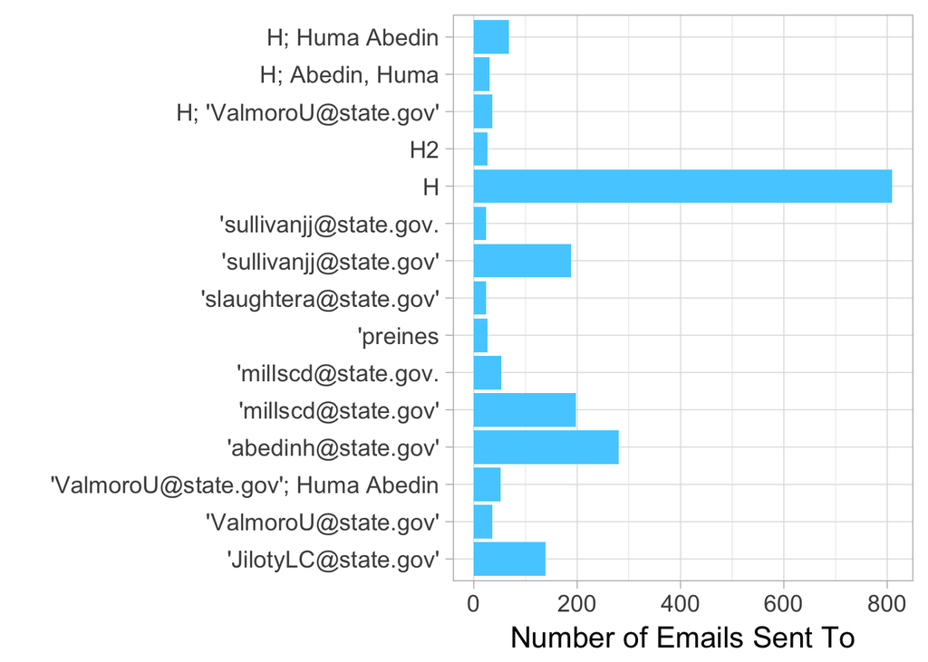

```r
cnt = count(emails_keep, ExtractedTo)
cnt_t = cnt[order( -cnt$n),]

cnt_t <- cnt_t[!(is.na(cnt_t$ExtractedTo) | cnt_t$ExtractedTo==""), ]

cnt_1 = cnt_t[1:15,]

library(ggplot2)
ggplot(cnt_1, aes(x=cnt_1$ExtractedTo, y=cnt_1$n)) +
  geom_bar(stat="identity", fill="#53cfff") +
  coord_flip() +
  theme_light(base_size=16) +
  xlab("") +
  ylab("Number of Emails Sent To") +
  theme(plot.title=element_text(size=14))
```

Now we are going find the top 15 senders of emails:

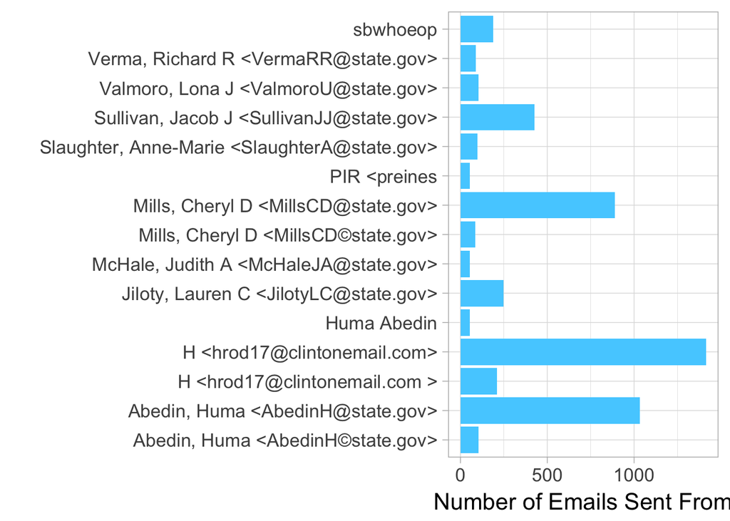

```r
cnt = count(emails_keep, ExtractedFrom)
cnt_t <-cnt[order( - cnt$n),]
cnt_t <- cnt_t[!(is.na(cnt_t$ExtractedFrom) | cnt_t$ExtractedFrom==""), ]
cnt_1 = cnt_t[1:15,]

ggplot(cnt_1, aes(x=cnt_1$ExtractedFrom, y=cnt_1$n)) +
  geom_bar(stat="identity", fill="#53cfff") +
  coord_flip() +
  theme_light(base_size=16) +
  xlab("") +
  ylab("Number of Emails Sent From") +
  theme(plot.title=element_text(size=14))
```

```r
require(stringdist)

df = unique(c(emails_keep$ExtractedTo ,emails_keep$ExtractedFrom))

string_distances = stringdistmatrix(df,df,method = "lv")

res = which((string_distances < 2) & (string_distances > 0) , arr.ind = TRUE)
print(length(res)/2)
```

```
## [1] 988
```

```r
for(i in 1:nrow(res)) {
    if(i < length(res)/10){
      row <- res[i,]
      if(row[1] <= row[2]){
        cat(sprintf("Similar: %s and %s \n", df[row[1]], df[row[2]]))
      }
    }
}
```

```
## Similar: 'sullivanjj@state.gov' and 'sullivanjj@state.gov`
## Similar: Mills, Cheryl D; Kennedy, Patrick F and Mills, Cheryl 0; Kennedy, Patrick F
## Similar:  and H
## Similar: 'hanleymr@state.gov' and hanleymr@state.gov'
## Similar: 'hanleymr@state.gov' and 'hanleymr@stategov'
## Similar: 'hanleymr@state.gov' and 'hanleymr@state.gov°
## Similar: 'sullivanjj@state.gov' and 'sullivanjj@state.gov.
## Similar: 'sullivanjj@state.gov` and 'sullivanjj@state.gov.
## Similar: 'Russorv@stategov' and •Russorv@stategov'
## Similar: 'Russorv@stategov' and 'Russorv@state.gov'
## Similar: 'Russorv@state.gov° and 'Russorv@state.gov'
## Similar: 'hanleymr@state.gov' and 'hanleymr@state.gov.
## Similar: 'hanleymr@state.gov° and 'hanleymr@state.gov.
## Similar: 'millscd@state.gov` and 'millscd@state.gov'
## Similar: 'millscd@state.gov` and 'millscd@state.gov.
## Similar: 'millscd@state.gov' and 'millscd@state.gov.
## Similar: 'rnillscd@state.gov' and 'rnillscd@state.gov's
## Similar: 'Jake.Sullivan and 'Jake.Sullivar
## Similar: 'JilotyLC@state.gov' and 'JilotyLC@state.gov.
## Similar: 'Jake.Sullivan and 'Jake.Sulliyan
## Similar: 'abedinh@state.gov and 'abedinh@state.gov'
## Similar: 'Jake.Sullivan and 'Jake.Sulliva
## Similar: 'Jake.Sullivar and 'Jake.Sulliva
## Similar: 'JilotyLC@state.gov' and 'filotyLC@state.gov'
## Similar: 'AbedinH@state.gov' and 'AbedinH@state.gov.
## Similar: 'millscd@state.gov' and 'millscd@state.aov'
## Similar: 'ValmoroU@state.gov'; 'HAbedin and 'ValmoroU@state.gov'; 'HAbedin(
## Similar: 'abedinh@state.gov and 'abedinh@state.goV
## Similar: 'sullivanjj@state.gov. and 'sullivanij@state.gov.
## Similar: 'abedinh@state.gov' and 'abedinh@state.goy'
## Similar: 'abedinh@state.gov' and 'a bedinh@state.gov'
## Similar: 'preines@ and 'preines
## Similar: 'preine and 'preines
## Similar: 'preines ; 'sullivanij@state.gov' and 'preines ; 'sullivanjj@state.gov'
## Similar: 'ValmoroLl@state.gov. and 'ValmoroLJ@state.gov.
## Similar: jake.sullivar and jake.sullivan
## Similar: 'millscd@state.gov'; 'sullivanjj@state.gov' and 'millscd@state.gov'; 'sullivanij@state.gov'
## Similar: 'abedinh@state.gov and 'abedinh@state.gov.
## Similar: 'abedinh@state.gov' and 'abedinh@state.gov.
## Similar: 'ValmoroLJ@state.gov. and 'ValmoroLJ@state.gov'
## Similar: 'wburns66 and 'wburns6
## Similar: 'ValmoroLl@state.gov. and 'ValmoroL1@state.gov.
## Similar: 'ValmoroLJ@state.gov. and 'ValmoroL1@state.gov.
## Similar: 'SteinbergiB@state.gov' and 'SteinbergJB@state.gov'
## Similar: 'SteinbergiB@state.gov' and 'Steinberg1B@state.gov'
## Similar: 'SteinbergJB@state.gov' and 'Steinberg1B@state.gov'
## Similar: 'JilotyLC@state.gov.; 'Russorv@state.gov' and 'JilotyLC@state.gov'; 'Russorv@state.gov'
## Similar: 'ValmoroU@state.gov'; 'abedinh@state.gov' and 'ValmoroU©state.gov'; 'abedinh@state.gov'
## Similar: 'sullivanjj@state.gov'; 'reinesp@state.gov' and 'sullivanij@state.gov'; 'reinesp@state.gov'
## Similar: 'millscd@state.gov' and emillscd@state.gov'
## Similar: 'JilotyLC@state.gov' and 'JilotyLC@state.goy'
## Similar: 'ValmoroU@state.gov' and 'ValmoroU@state.gov.
## Similar: 'ValmoroU@state.gov' and 'ValmoroU©state.gov'
## Similar: 'JilotyLC@state.gov'; Huma Abedin and JilotyLC@state.gov'; Huma Abedin
## Similar: 'a bedinh@state.gov' and 'a bed inh@state.gov'
## Similar: 'JilotyLC@state.gov. and 'JilotyLC©state.gov.
```

In total we have 988 pairs of words whose Edit Distance is less than 2 and greater than 0.  
With higher Edit Distances we had many more pairs but I decided to show only those below the threshold.  
This is quite a large number given that we have 1213 unique words (but this is also ~1.4million possible pairs).  
We also printed some examples of words which have the Edit Distance as decided by our threshold.

## 3. Advanced search using regular expressions

First we will prepare our dataset.

```r
df1 <- data.frame(paste(emails_keep$ExtractedSubject, emails_keep$ExtractedBodyText))
```

Next we will start using regular expressions.

#### 1. Looking for all emails that have a $ followed by numbers

```r
res = df1[grep("\\$[0-9]+", df1$paste.emails_keep.ExtractedSubject..emails_keep.ExtractedBodyText.), ]
if(length(res) > 0){
  head(res,1)
}
```

```
## [1] RE: Anything to report? Sorry — I've been flat out. (And I've agreed to have dinner with Anne-Marie at 7!)\n1. Well get you a new CGI draft tomorrow morning for you to noodle on. Feel free to'call when you've looked at it\nand we can talk about other directions if it doesn't feel right.\n2, T…
## 7461 Levels:   ... your legacy I just want to say that as I brief the QDDR (20 times and counting), one of the points that makes\nthe strongest impression, and that I frankly think is an enormous part of your intellectual and\npractical legacy, is putting together all the bureaus that focus on pr…
```

```r
sprintf("In total there is %i rows", length(res))
```

```
## [1] "In total there is 108 rows"
```

We found 108 emails in total containing a $ followed by numbers.

#### 2. Looking for all emails containing Benghazi

```r
res = df1[grep("Benghazi", df1$paste.emails_keep.ExtractedSubject..emails_keep.ExtractedBodyText.), ]
if(length(res) > 0){
  head(res,1)
}
```

```
## [1]  Anne-Marie Slaughter\nSunday, March 13, 2011 9:39 PM\nJacob Mills, Cheryl D; Reinesp@stategov; Abedin, Hurtle\npiece on libya nfz that will appear on NYT op-ed page tomorrow\nB6\nwanted to make sure you had a heads up. AM\nAnne-Marie Slaughter is a professor of politics and international aff…
## 7461 Levels:   ... your legacy I just want to say that as I brief the QDDR (20 times and counting), one of the points that makes\nthe strongest impression, and that I frankly think is an enormous part of your intellectual and\npractical legacy, is putting together all the bureaus that focus on pr…
```

```r
sprintf("In total there is %i emails", length(res))
```

```
## [1] "In total there is 46 emails"
```

We found 46 emails in total containing the word Benghazi.

#### 3. Looking for informal language, e.g. u ending with ? (e.g. How are u?)

```r
res = df1[grep("\\s+u\\?$", df1$paste.emails_keep.ExtractedSubject..emails_keep.ExtractedBodyText.), ]
if(length(res) > 0){
  head(res$ExtractedDateSent,10)
}
sprintf("In total there is %i emails", length(res))
```

```
## [1] "In total there is 0 emails"
```

We strangely didn’t find any emails where with a pattern " u?" was present.

#### 4. Locating early morning / late night emails (between 0-6 AM)

```r
res <- emails_keep[grep(" [^1-9]?[0-5](:|-)[0-5][0-9] AM", emails_keep$ExtractedDateSent), ]
if(length(res) > 0){
  head(res$ExtractedDateSent,10)
}
```

```
##  [1] "Thursday, September 13, 2012 2:31 AM"
##  [2] "Friday, September 14, 2012 5:59 AM"
##  [3] "Friday, October 12, 2012 1:51 AM"
##  [4] "Friday, May 6, 2011 2:07 AM"
##  [5] "Friday, October 21, 2011 5:17 AM"
##  [6] "Saturday, November 24, 2012 3:12 AM"
##  [7] "Tue 1/24/2012 2:25 AM"
##  [8] "Friday, February 24, 2012 5:24 AM"
##  [9] "Tuesday, April 28, 2009 5:40 AM"
## [10] "Wednesday, May 6, 2009 5:59 AM"
```

```r
sprintf("In total there is %i emails", nrow(res))
```

```
## [1] "In total there is 253 emails"
```

We found 253 emails in total sent in the early morning/ later night time.

#### 5. Looking for overmotive expression (at least two ! and ? exclamation marks)

```r
res <- df1[grep("(\\?|\\!){2,}", df1$paste.emails_keep.ExtractedSubject..emails_keep.ExtractedBodyText.), ]
if(length(res) > 0){
  head(res,10)
}
```

```
##  [1] Re: CHRIS HILL CONFIRMED Yeah!! Is he going w us?
##  [2] Re: Tom in Jamaica When will we hear from Paul Farmer???
##  [3] Fw: May 19-21 Can I fit in a visit at the State Dept??
##  [4] Re: Trying to reach you I tried you back. Don't know why I didn't heard the phone--I've been on it all am. Can you talk now??
##  [5] No WH mtg I arrived for the 10:15 mtg and was told there was no mtg. Matt said they had "released" the time. This is the second\ntime this has happened. What's up???
##  [6] Re: Schedule Can we leave closer to 8:30? Tomorrow changes ok altho I did tell WH I couldn't do at 5!!
##  [7]  H <hrod17@clintonemail.com>\nTuesday, June 30, 2009 5:59 PM\n'bam@mikulski.senate.gov'\nRe: Sorry to hear\nBarb--Thanks, my dear friend, for your good wishes.\nLet's try again for dinner soon. Happy 4th!! All the best, Hillary
##  [8] Thank you!! Derek---Thank you for all of your help and leadership on the speech and the policies it embodies. It is a delight working\nw you. All the best, Hillary
##  [9] Re: You were tern lc. Thx so much for your help--and for Ernie Banks! Let's play two!!
## [10] Re: Since the Secretary likes to track such things - The Associated Press: Rocker Juanes' wife gives birth to son in Miami\n??????????????????????????
## 7461 Levels:   ... your legacy I just want to say that as I brief the QDDR (20 times and counting), one of the points that makes\nthe strongest impression, and that I frankly think is an enormous part of your intellectual and\npractical legacy, is putting together all the bureaus that focus on pr…
```

```r
sprintf("In total there is %i emails", length(res))
```

```
## [1] "In total there is 69 emails"
```

We found 69 rows in total with a mix of at least two ! and ? exclamation marks

#### 6. Looking for mentions of a web address in the emails and calculating precision and recall (and ranked charts)

We are going to first extract websites that are mentioned in Hillary Clinton emails using a Regex.  
Then we will count how many times each occurs website.  
Lastly, we will compare our results with the perfect results.

```r
res2 = regmatches(df1$paste.emails_keep.ExtractedSubject..emails_keep.ExtractedBodyText., regexpr("www\\..*?\\.(co.uk|com|org|gov|net)", df1$paste.emails_keep.ExtractedSubject..emails_keep.ExtractedBodyText.))

length(res2[nchar(res2) > 30])
```

```
## [1] 6
```

```r
length(res2[nchar(res2) <= 30])
```

```
## [1] 81
```

```r
res2 = res2[nchar(res2) <= 30]

df= do.call(rbind.data.frame, as.list(res2))
df = setNames(df,"websites")

cnt = count(df, websites)
cnt_t2 = cnt[order( -cnt$n),]
top_10_sites = cnt_t2[1:10,1]
print("Top 10 websites found with our model")
```

```
## [1] "Top 10 websites found with our model"
```

```r
head(top_10_sites,10)
```

```
## # A tibble: 10 x 1
##    websites
##    <fct>
##  1 www.thedailybeast.com
##  2 www.ltstrategy.com
##  3 www.huffingtonpost.com
##  4 www.salon.com
##  5 www.ft.com
##  6 www.guardian.co.uk
##  7 www.myfoxdc.com
##  8 www.newyorker.com
##  9 www.nybooks.com
## 10 www.nytimes.com
```

```r
perfect_top_10_sites = c("www.guardian.co.uk", "www.thedailybeast.com", "www.nytimes.com", "www.newyorker.com", "www.washingtonpost.com","www.facebook.com",
"www.huffingtonpost.com","www.ft.com","www.messagelabs.com", "www.state.gov")
perf_top_10_sites= do.call(rbind.data.frame, as.list(perfect_top_10_sites))
perf_top_10_sites = setNames(perf_top_10_sites,"websites")

tp = nrow(intersect(top_10_sites,perf_top_10_sites))
fp = nrow(setdiff(top_10_sites,perf_top_10_sites))
fn = nrow(setdiff(perf_top_10_sites,top_10_sites))

precision = tp / (tp + fp)
recall = tp / (tp + fn)

sprintf("Precision %f", precision)
```

```
## [1] "Precision 0.600000"
```

```r
sprintf("Recall %f", recall)
```

```
## [1] "Recall 0.600000"
```

We got a precision score of 0.6 and a recall score of 0.6.  
These results aren’t really good but they aren’t that terrible.  
Now we are going to do a precision-recall chart for ranked results.

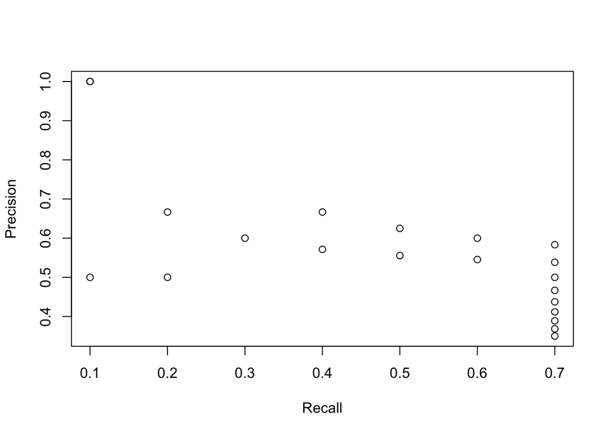

```r
x<-c()
y<-c()

cnt_t2 = cnt[order( -cnt$n),]
for (i in 0:20){
  top_i_sites = cnt_t2[1:i,1]
  tp = nrow(intersect(top_i_sites,perf_top_10_sites))
  fp = nrow(setdiff(top_i_sites,perf_top_10_sites))
  fn = nrow(setdiff(perf_top_10_sites,top_i_sites))

  precision = tp / (tp + fp)
  recall = tp / (tp + fn)

  x<-c(x,recall)
  y<-c(y,precision)
}

plot(unlist(x),unlist(y), ylab = "Precision", xlab = "Recall")
```

We notice that although the trend isn’t overly clear, higher precision rates occur with lower recall rates.  
Similarly higher recall rates tend to reduce the precision.

## 4. Data cleaning

4. remove punctuation marks
5. apply stemming
6. remove excess whitespaces

```r
require(tm)
library("SnowballC")
# basic cleaning
emails_keep$ExtractedBodyText <-  tolower(emails_keep$ExtractedBodyText)
emails_keep$ExtractedBodyText <- gsub('\\b\\w{1,3}\\b','',emails_keep$ExtractedBodyText)
emails_keep$ExtractedBodyText <- removeWords(emails_keep$ExtractedBodyText, stopwords("english"))
# additional stuff
emails_keep$ExtractedBodyText <- removePunctuation(emails_keep$ExtractedBodyText)
emails_keep$ExtractedBodyText <- stemDocument(emails_keep$ExtractedBodyText)
emails_keep$ExtractedBodyText <- stripWhitespace(emails_keep$ExtractedBodyText)

head(emails_keep$ExtractedBodyText,10)
```

```
##  [1] ""
##  [2] "thursday march 2011 latest syria aid qaddafi memo syria aid libya 030311docx memo syria aid libya 030311docx march 2011 hillari"
##  [3] ""
##  [4] ""
##  [5] "hrod17clintonemail friday march 2011 huma abedin latest syria aid qaddafi memo syria aid libya 030311docx print"
##  [6] "print • hrod17clintonernailcom wednesday septemb 2012 °russorvst meet rightw extremist behind antifvluslim film spark dead riot meat sent wednesday septemb 2012 subject meet right wing extremist behind antimuslim film spark dead riot httemaxbiumenthalcom12012meetrightwingextremistbehindanti…
##  [7] ""
##  [8] "hrod17clintonemailcorn friday march 2011 huma abedin latest syria aid qaddafi memo syria aid libya 030311docx print"
##  [9] ""
## [10] "wednesday septemb 2012 libya libya sept docx send direct just sent verizon wireless druid"
```

We can see that we successfully cleaned the strings.  
In addition to extra steps we took, we could also take other steps such as lemmatization, tokenization…

## 5. Per-sender TF-IDF and Vector Space Model

#### 1. Identifying the different persons from the ExtractedFrom column

We can notice that the persons name is alawys at the start of the ExtractedFrom column and the email address follows afterwards starting with ‘<’ character.  
Thus we are going to remove the email address part to focus only on the actual names.  
Also we will remove the leading and trailing whitespaces.  
Lastly we will visualize number of emails sent by each contact.

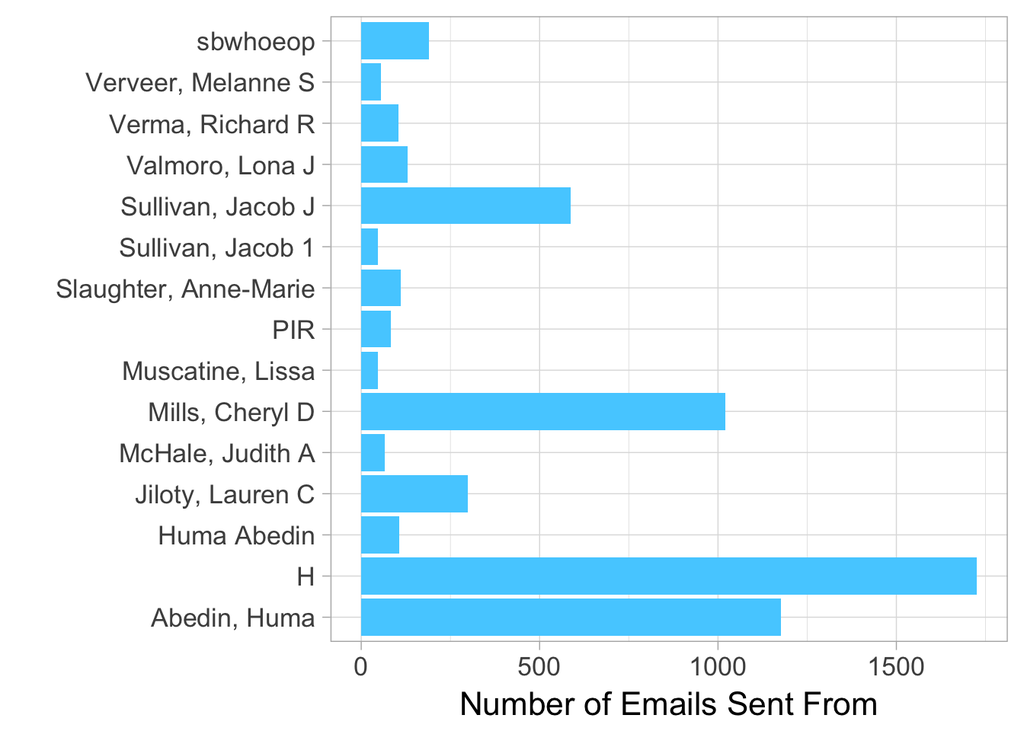

```r
emails_keep$ExtractedFrom <- gsub('<.*','',emails_keep$ExtractedFrom)
emails_keep$ExtractedFrom <- gsub('^\\s+|\\s+$','',emails_keep$ExtractedFrom)

cnt = count(emails_keep, ExtractedFrom)
cnt_t <-cnt[order( - cnt$n),]
cnt_t <- cnt_t[!(is.na(cnt_t$ExtractedFrom) | cnt_t$ExtractedFrom==""), ]
cnt_1 = cnt_t[1:15,]

ggplot(cnt_1, aes(x=cnt_1$ExtractedFrom, y=cnt_1$n)) +
  geom_bar(stat="identity", fill="#53cfff") +
  coord_flip() +
  theme_light(base_size=16) +
  xlab("") +
  ylab("Number of Emails Sent From") +
  theme(plot.title=element_text(size=14))
```

We can see that this is a pretty good way to extract only the names of actual persons.

#### 2. Concatenating all corresponding emails from each one of this person in one entry and cleaning the data

We will append all the emails a sender sent into a single entry.  
We don’t have to clean the data any further as we already did that in step 4.

```r
res = aggregate( ExtractedBodyText ~ ExtractedFrom, emails_keep, toString)
res_keep = res[ nchar(res$ExtractedBodyText) > 100, ]
```

#### 3. Using cosine distance to find who are the persons that are most similar to Hillary

After our data was cleaned and aggregated, we will build a corpus.  
From the corpus we will build a Term Document Matrix with TfIdf weighting and normalization.  
Then we will use the slam library to calculate the cosine distances.  
Lastly we will turn those distances into a dataframe and see whose emails are most similar to Hillary.

```r
corp = Corpus(VectorSource(res_keep$ExtractedBodyText))

tdm = TermDocumentMatrix(corp, control = list(weighting = function(x) weightTfIdf(x, normalize = TRUE)))
colnames(tdm) = c(res_keep$ExtractedFrom)
library(slam)
cosine_dist_mat <- 1 - crossprod_simple_triplet_matrix(tdm)/(sqrt(col_sums(tdm^2) %*% t(col_sums(tdm^2))))

df_res = as.data.frame(as.table(cosine_dist_mat))

df_hillary = df_res[df_res$Docs.1 == 'H',]

df_hillary_sorted = df_hillary[ order( df_hillary$Freq), ]
colnames(df_hillary_sorted) = c("person","person2","cosine distance")
head(df_hillary_sorted,20)
```

```
##                     person person2 cosine distance
## 5101                     H       H    4.440892e-16
## 5069          Abedin, Huma       H    4.204885e-01
## 5105           Huma Abedin       H    5.324105e-01
## 5172     Sullivan, Jacob J       H    5.547202e-01
## 5067                             H    5.811119e-01
## 5129       Mills, Cheryl D       H    5.984082e-01
## 5162 Slaughter, Anne-Marie       H    6.437522e-01
## 5140                   PIR       H    6.629517e-01
## 5124      McHale, Judith A       H    6.714548e-01
## 5068         Abed in, Huma       H    6.734895e-01
## 5206              sbwhoeop       H    6.842683e-01
## 5120       Lissa Muscatine       H    6.949682e-01
## 5187      Verma, Richard R       H    6.957750e-01
## 5170     Sullivan, Jacob 1       H    6.974249e-01
## 5135      Muscatine, Lissa       H    7.023348e-01
## 5102      Hanley, Monica R       H    7.031302e-01
## 5133      Mitchell, George       H    7.137554e-01
## 5145       Philippe Reines       H    7.221623e-01
## 5146    Reines, Philippe I       H    7.351111e-01
## 5183       Valmoro, Lona J       H    7.433351e-01
```

We can see that Huma Abedin who is Hillary Clinton’s assistant is most similar to Hillary (in terms of using the same terms).  
Jacob J Sullivan is second closes and he is her senior policy advisor.  
Cheryl D Mills was her chief of staff.  
So overall the results seem quite good and very reasonable.  
As we can also see Hillaries emails were most similar to themselves (as expected).